# Individual-based Integral Projection Models: The role of size-structure on extinction risk and establishment success

Sebastian Schreiber and Noam Ross

April 8, 2015

$\def\N{\mathbb N}$ $\def\R{\mathbb R}$ $\def\P{\mathbb P}$ $\def\N{\mathbb N}$ $\def\S{\mathcal S}$ $\def\n{\mathbf n}$ $\def\s{\mathbb s}$ $\def\x{\mathbf x}$ $\def\y{\mathbf y}$ $\def\o{\%*\%}$

## Introduction

Computations of extinction probabilities or likelihoods of establishment success lie on opposing sides of a theoretician’s coin and are used to address questions in conservation biology, restoration ecology, biological invasions and population genetics. Risks of extinction or establishment failure stem from populations consisting of a finite number of individuals each of which faces a non-zero risk of mortality on any given day. These risks are shaped, in part, by the size and composition of a population in which individuals may differ in age, size, geographical location, or other important characteristics influencing demography. When population structure is finite-dimensional (i.e. a finite number of age classes, stages, geographical locations), multi-type branching processes serve as the stochastic counterpart of matrix models (Harris 1963; Athreya and Ney 2004; Caswell 2001). These models allow one to examine how extinction risk or establishment success depend on the population size and its distribution across a finite number of states (e.g. ages, size classes, patches).

When collecting demographic data, one commonly makes continuous measurements (e.g. mass, length) about individuals. Consequently, since their introduction in the early 2000s, there has been a surge of interest in integral projection models (IPMs) that account for continuous population structure (Easterling, Ellner, and Dixon 2000; Ellner and Rees 2006; Rees and Ellner 2009; Childs et al. 2004; Ramula, Rees, and Buckley 2009; Jongejans et al. 2011; S. P. Ellner and Schreiber In press). As IPMs correspond to infinite-dimensional matrix models which are numerically approximated by finite-dimensional matrix models, many of the standard demographic concepts and methods for matrix models (e.g. stable state distributions, reproductive values, life table response experiments) extend to IPMs (Metcalf et al. 2013; Rees, Childs, and Ellner 2014; Merow et al. 2014).

Here, we describe individual-based counterparts of IPMs by making use of the theory of continuous-state branching processes introduce by Harris (1963). We present an analytical method, differing from Harris, for computing extinction probabilities for these individual-based IPMs. These methods are easily implemented numerically and circumvent running individual-based simulations to examine how extinction probabilities depend on continuous or discrete population structure. To illustrate the implementation of these methods, we introduce and analyze an individual-based IPM of the endangered alpine plant *Dracocephalum ausriacum*, which corresponds to a stochastic counterpart of the IPM developed by Nicole et al. (2011).

## The General Models and Methods

### The Individual Based IPM

We consider an individual-based model where the set of all possible individual states (e.g. age, size, etc.) lies in a compact metric space $X$. For example, for the standard size-structured IPM, $X=[a,b]$ corresponds to the range of sizes measured in the field. For models with a mixture of age and size structure, $X$ could be given by $\{1,\dots,T\}\times [a,b]$ where $T$ corresponds to the maximal age of an individual.

As we consider finite populations, the state of the population at any point of the time is characterized by the different sizes $(x_1,x_2,\dots, x_k)$ of individuals within the population and how many individuals there are of each these sizes $(n_1,n_2,\dots, n_k)$. Specifically, if there $n_1$ individuals of size $x_1$, $n_2$ individuals of size $x_2$,…, $n_k$ individuals of size $x_k$, then the state of the population is given by $(n_1,n_2,\dots, n_k; x_1,x_2,\dots, x_k)$. Following Harris (1963), the set of all possible population states is
$$\S= \{(\n,\x)=(n_1,\dots, n_k, x_1\dots , x_k): k,n_i\in \N, x_i \in X\} \cup \{0\}$$
where $\N=\{1,2,3,\dots\}$ denotes the natural numbers and $0$ is the extinction state corresponding to no individuals in the population.

Let $\s_t=( \n, \x)\in \S$ be the population state at time $t$. The dynamics of $\s_t$ are determined by a set of probabilistic rules that determine the contribution of each individual in the population to the population in next time step $t+1$. These “contributions” may correspond to an individual surviving and changing state (e.g. growing in size), or having offspring. Consistent with standard branching process theory, each individual in the population updates independent of all other individuals. The update rule for an individual of size $x$ is given by a probability measure $m(x,d\s)$ on the state space $\S$. Specially, the probability an individual in state $x$ contributes $\s$ individuals to the population in the next time step where $\s$ lies in a subset $A\subset \S$ equals
$$\P[\s_1\in A| \s_0 =(1,x)]=\int_A m(x,d\s)$$
where the left hand side reads “the probability the population state lies $A$ at time $t=1$ after initially having only one individual in state $x$.”

If the population state is currently $\s_t=(n_1,\dots,n_k,x_1,\dots,x_k)$, then the state $\s_{t+1}$ is determined as follows:

1. for each of the $n_1$ individuals in state $x_1$, randomly and independently choose the number of replacement individuals from distribution $m(x_1,d\,\s)$.
2. repeat step 1. for the types $x_2,\dots, x_k$.
3. determine the new population state by identifying the states of all individuals and counting the total number of individuals in each of these states.

This iterative algorithm can be used to create individual based simulations of the individual based IPM. As with any branching process, stochastic realizations of this process, with probability one, either go to extinction in finite time, or the population size grows without bound.

### Probability generating functionals and extinction probabilities

To define the pgf $\Psi$, we introduce the following notation: given a continuous function $h:X\to\R$ and $\s\in \S$, let
$$h^\s=
\left\{
\begin{array}{cc}
\prod_{i=1}^k h(x_i)^{n_i}&\mbox{ if }\s=(n_1,\dots,n_k,x_1,\dots,x_k)\\
1 &\mbox{ if }\s=0.
\end{array}
\right.$$
We define the pgf by
$$\Psi(h)(x)=\int h^\s \,m(x,d\s).\tag{*}$$
In words, $\Psi(h)(x)$ corresponds to the expected value of $h^\s$ due to the contributions of individuals in the next time step from an individual in state $x$. This requires integrating over all possible populations states in the next time step.

The utility of $\Psi$ for computing extinction probabilities follows from two facts. The first fact stems immediately from the definition: if $h_0$ is the zero function (i.e. $h_0(x)=0$ for all $x$), then
$$\Psi(h_0)(x)=\int 1 \,m(d\s,x)= \P[\s_1=0|\s_0=(1,x)]$$
is the probability the population goes extinct in one time step given that initially it consisted of one individual is state $x$. For the second fact, we define
$$\Psi^t(h)=\underbrace{\Psi(\Psi(\dots \Psi}_{\mbox{$t$ times}}(h)\dots))$$
to be the $t$-fold composition of $\Psi$ with itself. We claim that
$$\Psi^t(h_0)(x)=\P[\s_t=0|\s_0=(1,x)]=:E_t(x)\tag{**}$$
is the probability of extinction by time $t$ given that the population initially consisted of one individual in state $x$. To see why this fact is true, we argue by induction. The first fact proves that the statement holds for $t=1$. Now suppose the assertion holds for $t$, we will show it holds for $t+1$. On the event that $\s_1=(n_1,\dots,n_k,x_1,\dots,x_k)$ is the population state at time $1$, extinction occurs by time $t+1$ only if each of the lineages of the $n_1+\dots +n_k$ individuals go extinct in the next $t$ time steps. As the fates of these lineages are independent of one another, it follows that
$$\begin{aligned}
\P[s_{t+1}=0|\s_0=(1,x),\s_1=(n_1,\dots,n_k,x_1,\dots,x_k)]&= \prod_{i=1}^k \P[\s_t=0|\s_0=(1,x_i)]^{n_i}\\
&=\prod_{i=1}^k\left(\Psi^t(h_0)(x_i)\right)^{n_i}=\Psi^t(h_0)^{\s_1}
\end{aligned}$$
where the second equality follows from our inductive hypothesis. By the law of total probability
$$\P[s_{t+1}=0|\s_0=(1,x)]=\int [\Psi^t(h_0)]^\s \,m(d\s,x)$$
which, by definition, equals $\Psi^{t+1}(0)(x)$ as claimed.

Hence, equation (**) can be used to compute extinction probabilities iteratively. Furthermore, as individuals update independent of one another, the probability of the population going extinct by time $t$ for any initial condition $\s=(n_1,\dots,n_k,x_1,\dots,x_k)$ equals
$$\P[\s_t=0|\s_0=\s]=E_t^\s.$$
These analytic expressions allow us to efficiently compute extinction probabilities by constructing a numerical approximation of the pgf and iterating it with an initial condition of a zero vector which corresponds to the numerical approximation of the zero function.

As $E_0(x)\le E_1(x),\le E_2(x)\dots$ for any $x\in X$ and $E_t(x)\le 1$ for all $t$, there is a well defined limit corresponding to the probability of eventual extinction:
$$E_\infty(x):=\lim_{t\to\infty} E_t(x).$$
Using moment generating functionals and under suitable technical hypotheses, Harris showed that $E_\infty(x)<1$ for all $x$ if the dominant eigenvalue of the mean-field IPM is greater than one, and $E_\infty(x)=1$ for all $x$ otherwise.

## An Illustration with an Endangered Plant Species

To illustrate how these general methods can be applied to a data set, we develop an individual-based IPM based for the endangered alpine plant *Dracocephalum ausriacum*. This model will corresponds to an individual-based counterpart of the IPM developed by Nicole et al. (2011). The Austrian Dragonhead (*D. austriacum L.*,*Lamiaceae*) is a long- lived perennial plant that is listed as Vunerable by the World Conservation Union (Nicole et al. 2011). We use data collected by Nicole et al. (2011) in 2001-2002 to build the IPM.

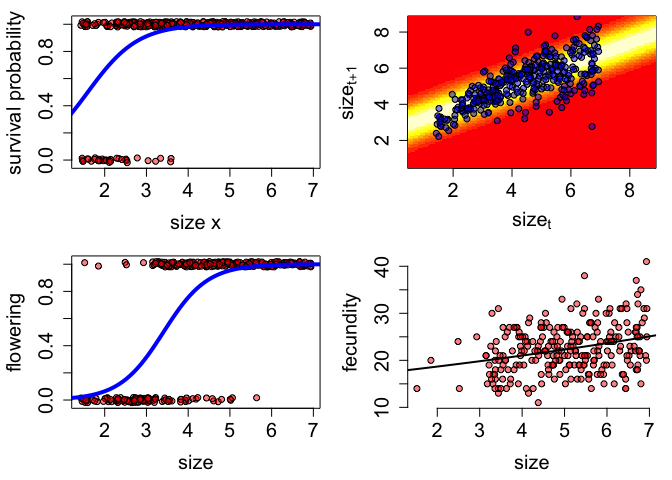

**Figure 1:** The demogrpahic kernels and the corresponding data.

The kernels $s(x)$, $G(y,x)$, $p(x)$ and $e(x)$ provide us with all the information that the individual-based IPMs requires for probabilistic updating individuals for survival, growth, flowering or not, and size at first census. The fecundity kernel $f(y)$, however, only specifies the mean number of offspring produced, but for an individual-based IPM, we need the distribution of the number of offspring produced by an individual. Fortunately, when using GLMs for the fecundity data, this extra information comes for free. For example, the fecundity data was modeled using a Poisson family for the GLM. In which case, the mean number $f(x)$ of offspring also specifies the distribution. More general, one might use multi-parameter distributions such as a zero inflated Poisson or a negative binomial in which case parameters beyond the mean are needed to specify the distribution of offspring number.

### Deriving the pgf $\Psi$

To define $\Psi$, we observe that the contributions of an individual of size $x$ to the population in the next time step involves the sum of two independent random variables: the contribution due to survival and growth and the contribution due to reproduction. We will identify the pgfs, $\Psi_g$ and $\Psi_f$, for each of these processes separately. Then, we make use of a fundamental property of pgfs:

> The pgf for a sum of independent random variables is the product of the pgfs of these random variables.

to get that
$$\Psi=\Psi_g \times \Psi_f.$$

When the random variables are identically, distributed, we have the following generalization of this fundamental property of pgfs:

> The pgf for a sum of $N$ independent, identically distributed random variables $X_i$ is the composition of the pgf for $N$ with the pgf for the $X_i$.

For the pgf $\Psi_g$ for survival and growth, $\Psi_g(h)(x)$ corresponds to integrating $h^\s$ over all possible contributions $\s$ from an individual of size $x$ surviving and growing. These contributions are of two types: $\s=\emptyset$ when the individual dies, and $\s=(1,y)$ when the individual survives and grows to size $y$. The first event occurs with probability $1-s(x)$ and the infinitesimal probability of the second event is $s(x)G(y,x)dy$. As $h^\s=1$ when $\s=\emptyset$ and $h^\s=h(y)$ when $\s=(1,y)$, integrating over all possible contributions due to survival and growth yields
$$\Psi_{g}(h)(x)=(1-s(x))\times 1 + s(x)\int h(y)G(y,x)dy.$$

For the pgf $\Psi_f$ corresponding to contributions due to fecundity, $\Psi_f(h)(x)$ is given by integrating $h^\s$ over all possible states $\s$ corresponding to the offspring produced by an individual of size $x$. To write this down, we apply the second fundamental property of pgfs twice. We begin by conditioning on the event that an individual of size $x$ flowers. On this event, the individual produces a Poisson number $N$ of offspring with mean $f(x)$. The size of each of these offspring is drawn interdependently from the common offspring distribution $e(y)dy$. Hence, the contribution of a flowering individual of size $x$ is the sum of $N$ independent random variables with distribution $e(y)dy$. By the second fundamental property of pgfs, we need to take the composition of the pgf for $N$, namely $\phi(x,\cdot)$, with the pgf for a single offspring, namely
$$\Psi_e(h)(x)=\int h(y)e(y)dy.$$
Thus, we get the pgf associated with a flowering individual is
$$\Psi_{flower}(h)(x)=\phi(x,\int h(y)e(y)dy)$$
To get the pgf for flowering and non-flowering contributions to fecundity, we observe that fecundity contributions of an individual of size $x$ is given by the “sum” of a Bernoulli number of flowering individuals where the probability of success is $p(x)$. Namely, we need to compose the pgf of a Bernoulli, which is $\theta(s)=1-p(x)+p(x)s$ where $s$ is the dummy variable, with the pgf of a flowering individual. This composition yields
$$\Psi_f (h)(x)=\theta(\Psi_{flower}(h)(x))=1-p(x)+p(s)\phi(x,\int h(y)e(y)dy)$$

Putting together the two pieces, we get the desired pgf $\Psi$:
$$\Psi(h)(x)=\left((1-s(x))\times 1 + s(x)\int h(y)G(y,x)dy\right)\phi(x,\int h(y)e(y)dy).$$
We note that this argument works did not rely on the form of the offspring pgf $\phi$. Hence, we can use the same expression for alternative offspring distributions as illustrate later.

### Numerically Implementing and Using the pgf $\Psi$

To create this probability generating functional numerically, we discretize the size interval $[\alpha,\beta]$ using $n$ equal sized intervals of width $dx=(\beta-\alpha)/n$. To use the midpoint rule to approximate the integrals, we created a vector $xs$ corresponding to the midpoints of these intervals. Using this vector we discretized the survival function as a vector $s.vec=s(xs)$, the growth kernel as a matrix using the outer product $g.mat=outer(xs,xs,g)$, the probability of flowering function as a vector $p.vec=p(xs)$, the fecundity function as a vector $f.vec=f(xs)$, and the offspring size distribution as a vector $e.vec=e(xs)$.

Using these discretized demographic components and the pgf $\phi$ for fecundity, we get the discretized pgf $\Psi$ is given by
$$\Psi_{discrete}(h)=s.vec\circ (g.mat^T\, h)+1-s.vec)\circ(1-p.vec+p.vec\circ phi(xs,e.vec^T\,h))$$
where $h$ corresponds to a discretized function i.e. a vector of length $n$, $^T$ denotes the transpose of a matrix or vector, and $\circ$ denotes element by element multiplication.

To scale things up to an entire population, recall that for a population initially in state $\s_0$, the extinction probability at time $t$ is $E_t^{\s_0}$. For example, Figure illustrates how the extinction probabilities over time vary for a population with initially $100$ individuals of the smallest size $\alpha$ versus a population with $5$ or $6$ individuals of the largest size $\beta$. This figure suggests that, from the extinction risk perspective, about $5$ or $6$ large individuals are equivalent to $100$ small individuals. These types of comparisons may be particularly useful when trying to assess whether planting germinates or adults are more effective for establishment success.

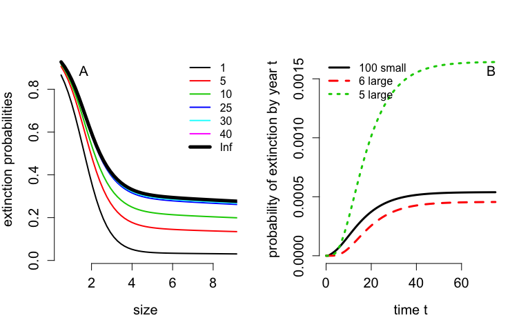

**Figure 2.** In A, extintion probabilities for a population consisting of a single individual of size $x$. Different curves corresond to extintion in different number of years. In B, extinction probabilities as a function of time for populations of different sizes and compositions.

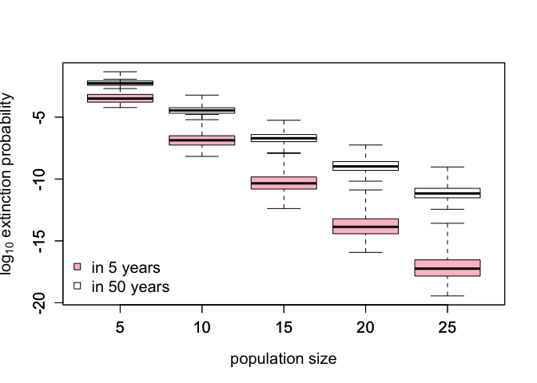

**Figure 3.** Extinction probabilities for populations of different sizes sampled for the $2001$ size distribution data. For each population size $N$, extinction probablities by year $5$ and year $50$ were calculated for $500$ samples of size $N$.

## Recommendations, Extensions, and Future Challenges

To implement the methods presented here, there are two main steps. First, one needs to identify the main demographic processes of the population, the order in which these processes occur relative to the censuses used for data collection, and develop the statistical models for the each of the demographic processes. Rees, Childs, and Ellner (2014) and Merow et al. (2014) provide excellent reviews on the philosophical and methodological issues associated with this step for mean-field IPMs. One like these mean-field IPMs, individual-based IPMs require complete distributional information associated with fecundity. As with other areas of stochastic demography, the shapes, not just the means, of these distribution can have significant effects on the likelihood of extinction. Hence, it is best to examine several options (e.g. Poisson, negative Binomial, zero-inflated distributions) to identify which distribution does a better job of describing the fecundity data. As in all areas of modeling, if there is signficant uncertainity about what is the ``best’’ model to use for the demographic analysis, then perform the analyses with each of the alternatives to identify the sensitivity of predictions of extinction risk to these distributional alternatives.

The second step, the focus of this paper, involves constructing the probability generating functional $\Psi$. For the uninitiated, this step can be quite intimidating. However, there are a three basic principles that simplify this construction. First, while this pgf $\Psi$ takes functions to functions, one shoud focus on writing down $\Psi(h)(x)$ which involves understanding the contributions of a single individual of size $x$ to the next census. Second, one can often can break up these contributions into a sum of independent contributions, find the pgfs associated with these simpler contributions, and then use the two fundamental properities of pgfs (see *Deriving the pgf $\Psi$*) to “stitch” together these simpler contributions to construct $\Psi$. Third, the distributions used to describe the number of offspring produced by an individual typically involve random variables (e.g. Poisson, negative binomial) for which their associated pgf is well-known and can be found easily e.g. Wikipedia. When in doubt, find a collaborator that you trust to put the pieces together correctly.

For the individual-based models considered here, we assumed the environment was constant. However, IPMs have and continue to be used to study the effects of fluctuating environmental conditions on population demography and life history evolution . The methods described here easily extended to fluctuating environments. Specifically, if $\Psi_t$ is the pgf of individual-based IPM associated with year $t$, then the probability of extinction for a population initially in state $\s$ is
$$\Psi_0(\Psi_1(\dots \Psi_t(h_0)))^\s$$
where $h_0$ as before is the zero function. Notice that the composition here is in the reverse order of what one does when iterating the mean-field IPM model forward in time. While we know of no formal proof, in the case of a stationary environment and under suitable technical assumptions, we conjecture the following limit theorem holds: the asymptotic extinction probabilities are strictly less than one if and only if the stochastic growth rate (aka dominant Lyapunov exponent) of the mean-field IPM is positive. For multi-type branching processes, this result was proven by Tanny (1981).

Despite this simple extension to temporally variable environments, many future challenges remain. From the computational perspective, finding the efficient methods to deal with multi-dimensional states variables (e.g. size and location, or multi-dimensional traits) is likely to be challenging, as it is for mean-field IPMs. While the analytical methods presented here cover multi-dimensional state variables, their numerical implementation involves approximating mutli-dimensional integrals which can be computationally expensive. From the analytical perspecitve, accounting for temporal correlations in individual growth or reproductive rates (e.g. individuals that grew larger than expected in one year being more likely to grow larger than expected in the next year) or correlations among individuals are particularly important problems as strong correlations likely have large effects on extinction risk. Finally, and perhaps most importantly, the manners in which size-structured demography may shape extinction risk for real-world population remains to be understand. One might hope that by applying these methods to the many data sets for which IPMs have been developed, as well as future data sets, might provide a computational efficients means to explore how size-structure for populations differing in their evolutionary history and environmental context influences their vulnerability to extinction.

References

Athreya, K. B., and P. E. Ney. 2004. *Branching Processes*. Mineola, NY: Dover Publications Inc.

Caswell, H. 2001. *Matrix Population Models*. Sunderland, Massachuesetts: Sinauer.

Childs, D.Z., M. Rees, K.E. Rose, P.J. Grubb, and S.P. Ellner. 2004. “Evolution of Size–dependent Flowering in a Variable Environment: Construction and Analysis of a Stochastic Integral Projection Model.” *Proceedings of the Royal Society of London. Series B: Biological Sciences* 271 (1537). The Royal Society: 425–34.

Easterling, M.R., S.P. Ellner, and P.M. Dixon. 2000. “Size-Specific Sensitivity: Applying a New Structured Population Model.” *Ecology* 81. Eco Soc America: 694–708.

Ellner, S. P., and S. J. Schreiber. In press. “Temporally Variable Dispersal and Demography Can Accelerate the Spread of Invading Species.” *Theoretical Population Biology*.

Ellner, S.P., and M. Rees. 2006. “Integral Projection Models for Species with Complex Demography.” *American Naturalist* 167. University of Chicago Press: 410–28.

Harris, T.E. 1963. *The Theory of Branching Processes*. Springer-Verlag.

Jongejans, E., K. Shea, O. Skarpaas, D. Kelly, and S. Ellner. 2011. “The Importance of Individual and Environmental Variation for the Spread of Invasive Species: A Spatial Integral Projection Model.” *Ecology* 92: 86–97.

Merow, C., J.P. Dahlgren, C.J.E. Metcalf, D.Z. Childs, M.E.K. Evans, E. Jongejans, S. Record, M. Rees, R. Salguero-Gómez, and S.M. McMahon. 2014. “Advancing Population Ecology with Integral Projection Models: A Practical Guide.” *Methods in Ecology and Evolution* 5. Wiley Online Library: 99–110.

Metcalf, C.J.E., S.M. McMahon, R. Salguero-Gómez, and E. Jongejans. 2013. “IPMpack: An R Package for Integral Projection Models.” *Methods in Ecology and Evolution* 4. Wiley Online Library: 195–200.

Nicole, F., J.P. Dahlgren, A. Vivat, I. Till-Bottraud, and J. Ehrlén. 2011. “Interdependent Effects of Habitat Quality and Climate on Population Growth of an Endangered Plant.” *Journal of Ecology* 99. Wiley Online Library: 1211–18.

Ramula, S., M. Rees, and Y.M. Buckley. 2009. “Integral Projection Models Perform Better for Small Demographic Data Sets Than Matrix Population Models: A Case Study of Two Perennial Herbs.” *Journal of Applied Ecology* 46. Wiley Online Library: 1048–53.

Rees, M., and S.P. Ellner. 2009. “Integral Projection Models for Populations in Temporally Varying Environments.” *Ecological Monographs* 79. Eco Soc America: 575–94.

Rees, M., D.Z. Childs, and S.P. Ellner. 2014. “Building Integral Projection Models: A User’s Guide.” *Journal of Animal Ecology* 83. Wiley Online Library: 528–45.

Tanny, D. 1981. “On Multitype Branching Processes in a Random Environment.” *Advances in Applied Probability* 13. Applied Probability Trust: 464–97.